# Analisando dados do Github - Parte 2

Luiz Fonseca

28 de julho de 2017

## O objetivo

Nesta análise iremos continuar explorando dados do github. Os dados brutos contém a contagem de quantas pessoas editaram arquivos com cada extensão de arquivo em cada dia de 2016 e 2017 no github. Os dados não são de todos os repositórios. Trata-se de uma amostra de alguns repositorios.

O objetivo é responder às seguintes questões:

1. Qual o mês que possui mais dispersão entre o número de alterações por dia? A dispersão é grande?
2. Para uma extensão qualquer escolhida, o número de contribuições se alteraram ao longo de 2016?

Após responder cada uma dessas perguntas depois iremos gerar uma nova pergunta que pode ser derivada das respostas obtidas.

## Primeira pergunta

**Qual o mês que possui mais dispersão entre o número de alterações por dia? A dispersão é grande?**

A ideia geral para responder a essa pergunta é utilizarmos o desvio padrão como métrica de dispersão e então utilizar a técnica de reamostragem com bootstrapping para inferirmos a partir da amostra de dados que temos o valor do desvio padrão para a população.

```r
# Carregando os dados
dados_github <- read.csv("https://raw.githubusercontent.com/nazareno/fpcc2/master/datasets/github-users-committing-filetypes.csv")

# Renomeia as colunas
names(dados_github) <- c("extension", "month_day", "month", "year", "users")
```

Para simplificar o trabalho, utilizarei apenas os dados do ano 2016, porque para o ano de 2017 não há dados de todos os meses.

Temos que levar em consideração que há extensões que são bem mais alteradas do que outras e isso pode afetar no resultado de qual mês possui mais dispersão, pois a dispersão entre extensões será considerada. Para resolver essa questão vamos selecionar apenas extensões que possuem uma mediana de alterações diárias parecida.

```r
library(tidyverse)
library(ggplot2)
library(plotly)
set.seed(123)

# Filtra os dados somente do ano 2016
dados_2016 <- dados_github %>% filter(year == 2016)

# Verificando se há a contagem certa de dias para cada mês do ano
dias_por_mes <- dados_2016 %>%
  group_by(year, month) %>%
  summarise(dias = length(unique(month_day)))
# Confirmado. Para 2016, há dados de todos os dias de cada mês

# Medianas do número de alterações diárias para cada extensão"
extensoes <- dados_2016 %>%
  group_by(extension) %>%
  summarise(median = median(users)) %>%
  arrange(median)
```

Pelo gráfico abaixo temos uma ideia sumarizada do número de alterações diárias de arquivos de cada extensão.

```r
ggplotly (
  ggplot(extensoes, aes(x = "", y = median)) +
    geom_boxplot() +
    labs(x = "", y = 'mediana', title = "Medianas do número de alterações diárias para cada extensão")
)
```

[interactive chart not shown]

Podemos ver que temos duas extensões (md e js) que possuem uma mediana alta de alterações diárias. Estas extensões não são representativas do todo, pois a maioria possuem bem menos alterações por dia. De fato, metade das extensões possui uma mediana abaixo de 847 alterações por dia. A menor mediana é de 506. Então vamos selecinar essas extensões que representam 50% das extensões que temos e o valor mediano de alterações por dia é entre 506 e 847.

```r
# Filtrando as extensoes que vamos usar
extensoes <- extensoes %>% filter(median < 847)

dados_2016 <- dados_2016 %>%
  filter(extension %in% extensoes$extension)
```

Agora que selecionamos as extensões vamos realizar o processo de reamostragem para identificarmos a dispersão de cada mês.

```r
set.seed(123)

# Função que recebe um vetor, faz uma reamostragem desse vetor e depois
# retorna o desvio padrão dos valores do vetor.
resample_sd <- function(vector) {
  sample <- sample(vector, size = NROW(vector), replace = TRUE)
  return(sd(sample))
}

# o número de amostras que iremos criar com o bootstrapping.
repeticoes <- 5000
# a região crítica, isto é, a porcentagem inversa ao nível de confiança
alpha <- 0.05

# função que executa a reamostragem várias vezes e no final retorna o intervalo de confiança
# para o desvio padrão
bootstrap_sd <- function(vector, repetitions, alpha) {

  results <- data_frame(i = 1:repetitions) %>%
  rowwise() %>%
  mutate(sd = resample_sd(vector))

  percentis = quantile(results$sd, probs = c(alpha/2, 1 - alpha/2))
  sd <- summary(results$sd)['Median']
  lower <- percentis[1]
  upper <- percentis[2]

  return(c(sd = sd, lower = lower, upper = upper))
}

resultado1 <- data.frame()

# Faz o bootstrap para cada mês
for (mes in 1:12) {
  dados_mes <- dados_2016 %>% filter(month == mes)
  CI <- bootstrap_sd(dados_mes$users, repeticoes, alpha)
  sumario <- c(month = mes, CI)
  resultado1 <- rbind(resultado1, sumario)
}

names(resultado1) <- c('month', 'sd', 'lower', 'upper')
```

O gŕafico abaixo mostra os intervalos de confiança do desvio padrão encontrados para cada mês do ano.

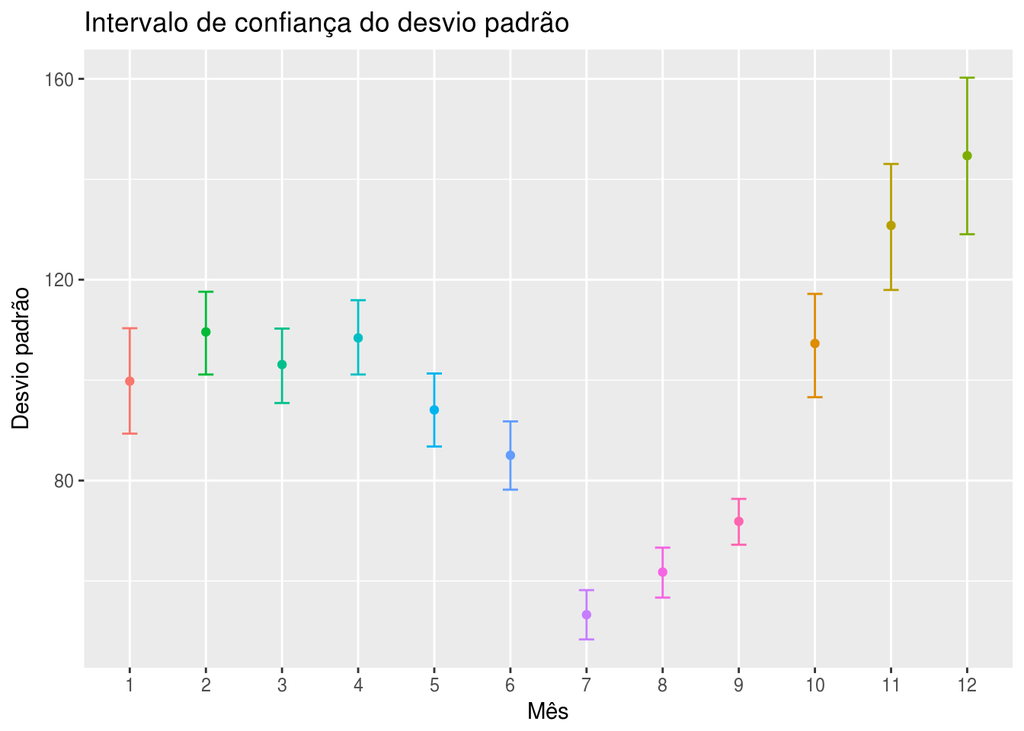

```r
ggplot(resultado1, aes(x = as.factor(month), color = as.character(month))) +
  geom_errorbar(aes(ymin = lower, ymax = upper), width = 0.2) +
  geom_point(aes(x = as.factor(month), y = sd)) +
  guides(color=FALSE) +
  labs(title = "Intervalo de confiança do desvio padrão" , x = "Mês", y = "Desvio padrão", color = "")
```

Analisando os intervalos de confiança sabemos (com 95% de confiança) que novembro e dezembro são os meses com mais dispersão. Entretanto, entre estes dois não sabemos qual o que possui mais dispersão pois os seus intervalos estão sobrepostos. A partir dessa resposta podemos gerar uma nova pergunta:

**Será que para uma única extensão, há diferença na dispersão de alterações de arquivos entre os meses de novembro e dezembro?**

Vamos tentar responder essa questão.

Vamos escolher três extensões e verificar individualmente se existe diferença de dispersão entre novembro e dezembro.

```r
# Selecionando extensões
extensoes_selecionadas <- dados_github %>% filter(year == 2016, extension %in% c("js", "java", "py"))

resultado2 <- data.frame()

for (ext in c("js", "java", "py")) {
  for (mes in 11:12) {
    dados_mes <- extensoes_selecionadas %>% filter(extension == ext, month == mes)
    CI <- bootstrap_sd(dados_mes$users, repeticoes, alpha)
    sumario <- c(extension = ext, month = mes, CI)
    resultado2 <- rbind(resultado2, sumario, stringsAsFactors = FALSE)
  }
}

names(resultado2) <- c('extension', 'month', 'sd', 'lower', 'upper')
```

O gráfico abaixo mostra os intrevalos de confiança do desvio padrão do número de alterações de usuários para as três extensões escolhidas e para cada um dos meses (novembro e dezembro).

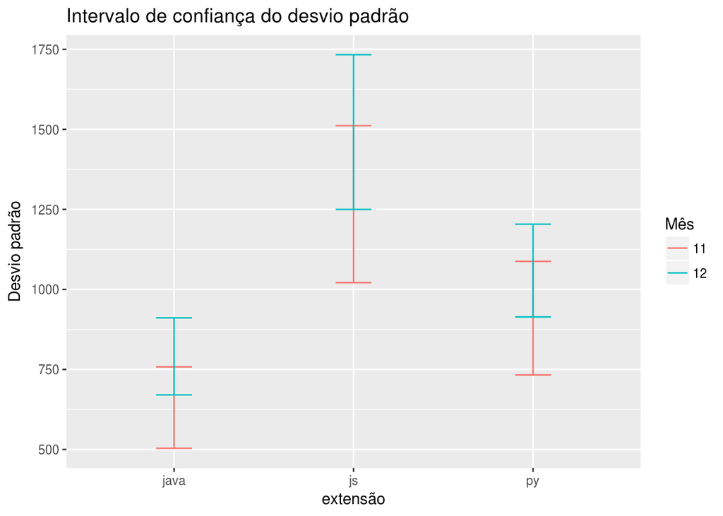

```r
ggplot(resultado2, aes(x = extension, color = as.character(month))) +
  geom_errorbar(aes(ymin = as.numeric(lower), ymax = as.numeric(upper)), width = 0.2) +
  # geom_point(aes(x = as.factor(month), y = sd)) +
  labs(title = "Intervalo de confiança do desvio padrão" , x = "extensão", y = "Desvio padrão", color = "Mês")
```

# Segunda Pergunta

**Para uma extensão qualquer escolhida, o número de contribuições se alteraram ao longo de 2016?**

Vamos fazer essa verificação para a extensão java. A ideia é calcular o intervalo de confiança da média de alterações para cada mês de 2016 e verificar o comportamento desses intervalos.

```r
set.seed(123)

# Dados que vamos usar
dados_java <- dados_github %>% filter(extension == 'java', year == 2016)

# Função que recebe um vetor, faz uma reamostragem desse vetor e depois
# retorna a média dos valores do vetor.
resample_mean <- function(vector) {
  sample <- sample(vector, size = NROW(vector), replace = TRUE)
  return(mean(sample))
}

# função que executa a reamostragem várias vezes e no final retorna o intervalo de confiança
# para a média
bootstrap_mean <- function(vector, repetitions, alpha) {

  results <- data_frame(i = 1:repetitions) %>%
  rowwise() %>%
  mutate(mean = resample_mean(vector))

  percentis = quantile(results$mean, probs = c(alpha/2, 1 - alpha/2))
  mean <- summary(results$mean)['Median']
  lower <- percentis[1]
  upper <- percentis[2]

  return(c(mean = mean, lower = lower, upper = upper))
}

resultado3 <- data.frame()

# Faz o bootstrap para cada mês
for (mes in 1:12) {
  dados_mes <- dados_java %>% filter(month == mes)
  CI <- bootstrap_mean(dados_mes$users, repeticoes, alpha)
  sumario <- c(month = mes, CI)
  resultado3 <- rbind(resultado3, sumario)
}

names(resultado3) <- c('month', 'mean', 'lower', 'upper')
```

O gráfico abaixo mostra o resultado da execução do bootstrap.

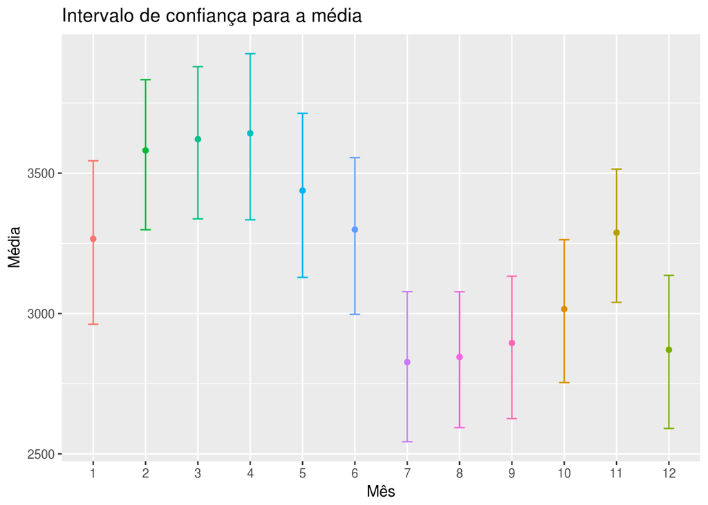

```r
ggplot(resultado3, aes(x = as.factor(month), color = as.character(month))) +
  geom_errorbar(aes(ymin = lower, ymax = upper), width = 0.2) +
  geom_point(aes(x = as.factor(month), y = mean)) +
  guides(color=FALSE) +
  labs(title = "Intervalo de confiança para a média" , x = "Mês", y = "Média")
```

A partir do gŕafico podemos dizer (com 95% de confiança) que nos meses 2, 3 e 4, por exemplo, há mais alterações de usuários do que nos meses 7, 8, 9. Não Podemos afirmar o quão grande é essa diferença.

Respondendo à pergunta feita, podemos dizer que sim, houve alteraçao no número de contribuições para arquivos java ao longo de 2016. Não sabemos se a diferença é significativa ou se é pequena, mas sabemos que em pelo menos 3 mêses de 2016 (fevereiro, março, abril) o número médio de alterações em arquivos java é maior do que em pelo menos outros três meses (julho, agosto, setembro).

A partir dessa resposta podemos derivar uma nova questão:

**O quão grande é a diferença do número médio de alterações da extensão java entre os meses fevereiro, março e abril e os meses julho, agosto e setembro?**

Agora iremos saber o valor da diferença que descobrimos que existe na resposta anterior.

```r
set.seed(123)

dados_java_filtered <- dados_java %>%
  filter(month %in% c(2, 3, 4, 7, 8, 9))

# Função que recebe um vetor, faz uma reamostragem desse vetor e depois
# retorna a diferença entre a média dos meses 2, 3 e 4 e a média dos meses 7, 8 e 9.
resample_diff <- function(dataset) {
  sample <- sample(dataset, size = NROW(dataset), replace = TRUE)
  months234 <- sample %>% filter(month %in% c(2,3,4))
  months789 <- sample %>% filter(month %in% c(7,8,9))
  mean234 <- mean(months234$users)
  mean789 <- mean(months789$users)
  return(mean234 - mean789)
}

# função que executa a reamostragem várias vezes e no final retorna o intervalo de confiança
# para a diferença entre as médias dos meses.
bootstrap_diff <- function(vector, repetitions, alpha) {

  results <- data_frame(i = 1:repetitions) %>%
  rowwise() %>%
  mutate(diff = resample_diff(vector))

  percentis = quantile(results$diff, probs = c(alpha/2, 1 - alpha/2))
  diff <- summary(results$diff)['Median']
  lower <- percentis[1]
  upper <- percentis[2]

  return(c(diff = diff, lower = lower, upper = upper))
}

CI <- bootstrap_diff(dados_java_filtered, repeticoes, alpha)

resultado4 <- data_frame(diff = round(CI[1]), lower = round(CI[2]), upper = round(CI[3]))
```

O gráfico abaixo mostra o resultado da execução do bootstrap

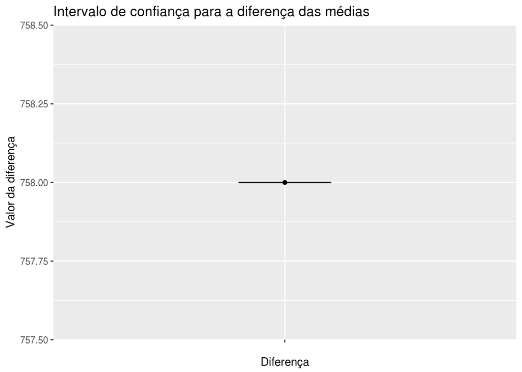

```r
ggplot(resultado4, aes(x = "")) +
  geom_errorbar(aes(ymin = lower, ymax = upper), width = 0.2) +
  geom_point(aes(x = "", y = diff)) +
  labs(title = "Intervalo de confiança para a diferença das médias" , x = "Diferença", y = "Valor da diferença")
```

De qualquer forma, respondendo à pergunta, sabemos que para este caso de java, de acordo com a nossa amostra, a diferença é de 758 alterações entre a média de alterações dos meses fevereiro, março e abril e a média de alterações dos meses julho, agosto e setembro.